# Lab 4. Modeling trends

Daniel Runcie. Modified from labs designed by Iago Hale, Dario Cantu and Jorge Dubcovsky

Necessary packages:

```r
library(ggplot2)
library(emmeans)
```

# Analysis of data from multiple treatments

This lab will use the dataset presented in lecture:

An experiment was run to evaluate effects of increased nitrogen fertilization on tuber yield of Alpine Russet potatoes

- 5 nitrogen regimes: 0, 90, 150, 210, 270 lbs / acre at emergence
- 10 reps / treatment combination
- Response: total yield

## Load data and inspect

```r
alpine_potato = read.csv('Alpine_Russet_yield.csv')
str(alpine_potato)
```

```
'data.frame':   50 obs. of  3 variables:
 $ Plot    : int  1 2 3 4 5 6 7 8 9 10 ...
 $ Nitrogen: int  270 0 210 150 150 90 270 210 270 90 ...
 $ Yield   : int  414 355 446 458 473 411 405 421 422 365 ...
```

## Design table

**Design**: Completely Randomized Design (CRD)

| Structure | Variable | Type | # levels | Experimental Unit |
| --- | --- | --- | --- | --- |
| Treatment | Nitrogen | Categorical | 5 | Plot |
| Design | Plot | Categorical | 50 |  |
| Response | Yield | Numeric | 50 |  |

We have two choices for the **Type** column for Nitrogen - Numeric or Categorical. R will choose Numeric by default, but the correct choice depends on your analysis goals.

We will start with analyzing the data with Nitrogen as a Categorical variable. To do this, we will create a new variable called **NitrogenFactor**. It will contain the same information, but will lead to a different analysis.

```r
alpine_potato$NitrogenFactor = as.factor(alpine_potato$Nitrogen)
str(alpine_potato)
```

```
'data.frame':   50 obs. of  4 variables:
 $ Plot          : int  1 2 3 4 5 6 7 8 9 10 ...
 $ Nitrogen      : int  270 0 210 150 150 90 270 210 270 90 ...
 $ Yield         : int  414 355 446 458 473 411 405 421 422 365 ...
 $ NitrogenFactor: Factor w/ 5 levels "0","90","150",..: 5 1 4 3 3 2 5 4 5 2 ...
```

### Plot the data

Since we don’t have subsamples, plotting the data is similar to plotting for Lab 2. We don’t have to worry about estimating the experimental units like we did in Lab 3.

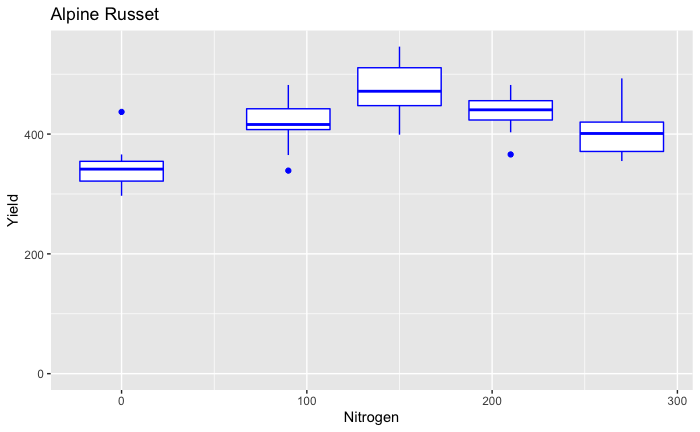

```r
library(ggplot2)
ggplot(alpine_potato,aes(x=Nitrogen)) +
    geom_boxplot(aes(y=Yield,group = Nitrogen),color = 'blue',position = position_identity()) +
  # note: when x is a continuous variable, we must use 'group' to get boxes
    ggtitle('Alpine Russet') + expand_limits(y=0)
```

## Analysis as Factors

By now, you should be comfortable analyzing this the data from this experiment. You should be able to:

1. Write a model for the data, treating `Nitrogen` as a Categorical variable (ie a **Factor**)
2. Run diagnostic tests
3. Form confidence intervals for comparisons among all pairs of treatments, or each treatment vs the control

Before continuing, ensure you can answer these questions:

> Are linear model assumptions satisfied for these data? Can you identify any pairs of treatments that differ. Which test will you use?

The code below will perform these analyses:

### Fit Factor model

```r
factor_model <- lm(Yield ~ NitrogenFactor, alpine_potato)
```

### Run diagnostics

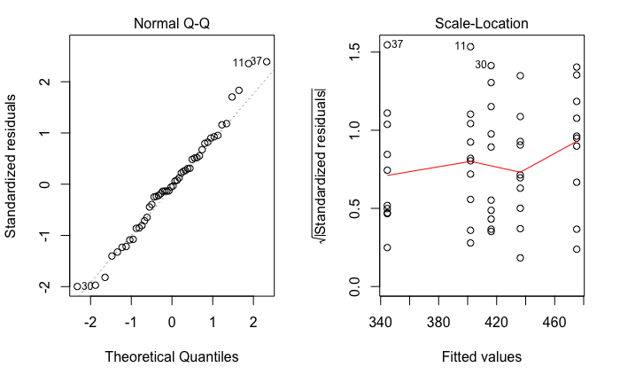

```r
par(mfrow=c(1,2))
plot(factor_model,which=2:3)
```

### Form confidence intervals on differences

```r
library(emmeans)
factor_means <- emmeans(factor_model,'NitrogenFactor')
factor_differences <- contrast(factor_means,'pairwise')
summary(factor_differences,level = 0.9, infer=T)
```

```
 contrast  estimate   SE df lower.CL upper.CL t.ratio p.value
 0 - 90       -71.6 18.2 45  -117.85    -25.4 -3.931  0.0026
 0 - 150     -130.6 18.2 45  -176.85    -84.4 -7.169  <.0001
 0 - 210      -91.7 18.2 45  -137.95    -45.5 -5.034  0.0001
 0 - 270      -57.4 18.2 45  -103.65    -11.2 -3.151  0.0230
 90 - 150     -59.0 18.2 45  -105.25    -12.8 -3.239  0.0182
 90 - 210     -20.1 18.2 45   -66.35     26.1 -1.103  0.8038
 90 - 270      14.2 18.2 45   -32.05     60.4  0.780  0.9352
 150 - 210     38.9 18.2 45    -7.35     85.1  2.135  0.2234
 150 - 270     73.2 18.2 45    26.95    119.4  4.018  0.0020
 210 - 270     34.3 18.2 45   -11.95     80.5  1.883  0.3411

Confidence level used: 0.9
Conf-level adjustment: tukey method for comparing a family of 5 estimates
P value adjustment: tukey method for comparing a family of 5 estimates
```

> Questions:

> Can you say if any of the +N treatments increased yield relative to N=0? Which? Is this the correct test for this question? Can you distinguish any of the +N treatments? Which?

For the first question, this could be the correct test if you also were interested in the 2nd. But if your interest was actually only in comparisons to the control, you would have more power if you use the ‘trt.vs.ctrl’ (Dunnett) test.

### Run an ANOVA

In class, we discussed the difference between the Tukey method and ANOVA.

Tukey allows you to test all pairs of treatments to identify which are different. Here, this involves 10 questions.

ANOVA allows you to ask the single question: Are any treatments different?

You can run an ANOVA like this:

```r
anova(factor_model)
```

```
Analysis of Variance Table

Response: Yield
               Df Sum Sq Mean Sq F value    Pr(>F)
NitrogenFactor  4  92042 23010.6  13.868 1.901e-07 ***
Residuals      45  74664  1659.2
---
Signif. codes:  0 ‘***’ 0.001 ‘**’ 0.01 ‘*’ 0.05 ‘.’ 0.1 ‘ ’ 1
```

From this output, check the following:

> Why is Df for Nitrogen equal to 4? Is MST = SST/DfT? Is MSE = SSE/DfE? Is F = MST/MSE? Is there evidence that any of the treatments are different? Can you identify which treatments differ?

From the Tukey output, we see that there is strong evidence that at least a few pairs of treatments differ. The p-values are truncated in the output, but we can extract the smallest p-value like this:

```r
all_contrasts_data <- as.data.frame(factor_differences)
min(all_contrasts_data$p.value)
```

```
[1] 5.627236e-08
```

> Notice that this is very similar to the p-value of the ANOVA. Why is this?

## Analysis as Trend

The above analysis is not very satisfying for this experiment. We can identify that adding Nitrogen tends to increase yield, but how much is best? We have little ability using Tukey to say which level is best. We also can’t say anything about possible Nitrogen application rates between say 90lbs and 150lbs.

The goals of a trend analysis are to create a model that predicts the response (Yield) for any value of Nitrogen application. In building a model, we will have to worry about both bias and precision. The general strategy will be:

1. Fit a fully-parameterized trend model
2. Use ANOVA to test if a reduced (ie more parsimonious) model will be sufficient
3. Use the model to generate predictions and confidence intervals for yield at specific Nitrogen levels

### Fit a trend model

To fit a fully-parameterized trend model, do this:

```r
full_trend <- lm(Yield ~ I(Nitrogen) + I(Nitrogen^2) + I(Nitrogen^3) + I(Nitrogen^4),alpine_potato)
```

**Note 1:** here we use `Nitrogen` (the Numeric variable) instead of `NitrogenFactor`

**Note 2:** to raise the value of `Nitrogen` to a power, you have to enclose it in the `I()` function.

**Note 3:** See below for a faster way of writing this model

### Use ANOVA to try to reduce the model

We can evaluate the fit by looking at an ANOVA table

```r
anova(full_trend)
```

```
Analysis of Variance Table

Response: Yield
              Df Sum Sq Mean Sq F value    Pr(>F)
I(Nitrogen)    1  23697   23697 14.2822 0.0004603 ***
I(Nitrogen^2)  1  60495   60495 36.4608 2.739e-07 ***
I(Nitrogen^3)  1    902     902  0.5436 0.4647527
I(Nitrogen^4)  1   6948    6948  4.1876 0.0465906 *
Residuals     45  74664    1659
---
Signif. codes:  0 ‘***’ 0.001 ‘**’ 0.01 ‘*’ 0.05 ‘.’ 0.1 ‘ ’ 1
```

> Questions

> Compare the ANOVA to the ANOVA from the factor model. What is different? What is the same? If you were to make diagnostic plots, how would they compare to the factor_model above? Why?

**Note**: When evaluating linear model assumptions in a trend analysis, evaluate them BOTH for the fully-specified model and for the reduced model if you choose a reduce model.

We evaluate the model by inspecting the `Sum Sq` and `Pr(>F)` columns. Starting from the highest-order term of the polynomial, we inspect it’s SST and p-value. If the p-value is small, this means that there is evidence in the data that this term is important. If the SST is large, it means that this term explains a large amount of the variance (ie sums of squared differences) of the observations. We should use both of these to decide if the term can be dropped.

> Here, the N^4 term is border-line important. It explains some variance, but not nearly as much as the order 1 and 2 terms. The N^3 term is clearly unimportant. But we can’t drop it unless we drop N^4 as well. The N^2 term is very important. We will definitely keep this term (and so also N^1)

We will compare both the degree-2 and degree-4 models below.

**Note**: If we select the degree-4 model, it means that we **cannot** safetly make predictions at new levels of Nitrogen. We’d need a new experiment!

### Create plots of the model fits

It can also be helpful to actually visualize the trend fits.

**The code below is difficult. Use it as a template for other assignments.**

We first create a new data tables to hold the predicted values for each model. We then use `emmeans` to predict the Yield at each intermediate value of Nitrogen.

```r
# Create a new data.frame with the set of Nitrogen values we want to plot the trends
predicted_data <- data.frame(Nitrogen = seq(0,300,length=100))
```

Get predicted values for the full model using `emmeans()` and append the values to the data.frame

```r
full_trend_means = emmeans(full_trend,spec = 'Nitrogen',at=list(Nitrogen = predicted_data$Nitrogen))
predicted_data$full_trend = as.data.frame(full_trend_means)$emmean
```

Now, we fit a reduced model with only degree=2, and get predicted yields with `emmeans()` and append these values to the data.frame

```r
reduced_trend <- lm(Yield ~ I(Nitrogen) + I(Nitrogen^2),alpine_potato)
reduced_trend_means = emmeans(reduced_trend,spec = 'Nitrogen',at=list(Nitrogen = predicted_data$Nitrogen))
predicted_data$reduced_trend = as.data.frame(reduced_trend_means)$emmean
```

Now, we can add these trends to our plot of the data

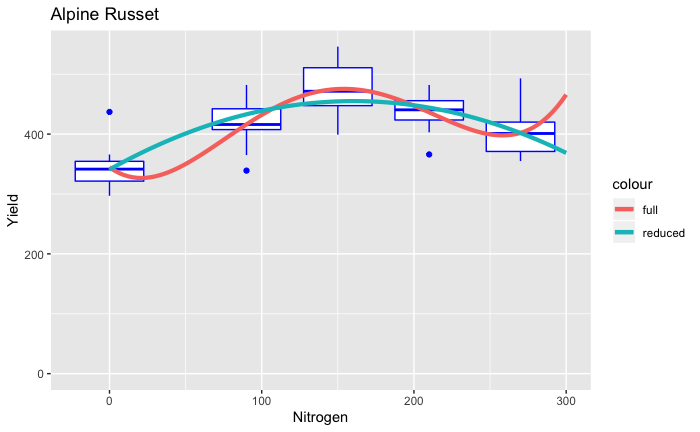

```r
ggplot(alpine_potato,aes(x=Nitrogen)) +
    geom_boxplot(aes(y=Yield,group = Nitrogen),color = 'blue',position = position_identity()) +
    ggtitle('Alpine Russet') + expand_limits(y=0) +
    geom_line(data = predicted_data,aes(y=full_trend,color = 'full'),size=1.5) +
    geom_line(data = predicted_data,aes(y=reduced_trend,color = 'reduced'),size=1.5)
```

> Questions

> Evaluate the differences in bias between the two models. Are either consistently biased? Are they biased at particular levels of Nitrogen?

### Creating predictions at particular values of Nitrogen

We can use a trend model to predict responses at intermediate values between our treatments.

For a prediction, we want to be able to provide:

1. a best-guess value
2. A confidence interval

As always, the confidence intervals is estimate +/- critical_value * SE_hat

- The estimate will come from the **explanatory component** of the model
- The critical value will come from a t-distribution. We don’t need to adjust for multiple comparisons because we are only making a single prediction.
- The estimated standard error will depend on both MSE and sample size. We can let the `predict` function calculate this

Let’s make a confidence interval for Nitrogen = 120lbs for the reduced model. We can use the `emmeans` function for this. We specify that we are predicting across Nitrogen levels, and then use `at = list(Nitrogen = 120)` to specify that we want an estimate and confidence interval at 120lbs.

```r
reduced_trend_means = emmeans(reduced_trend,'Nitrogen',at=list(Nitrogen = 120))
summary(reduced_trend_means,level = 0.8,infer = c(T,F))
```

```
 Nitrogen emmean   SE df lower.CL upper.CL
      120    448 8.97 47      436      459

Confidence level used: 0.8
```

> You should be able to calculate these confidence intervals yourself, taking the estimate (‘emmean’), SE and df from above. Do so here:

Similarly, we can predict the **effect** of a new level of Nitrogen relative to Nitrogen = 0

```r
reduced_trend_means = emmeans(reduced_trend,'Nitrogen',at=list(Nitrogen = c(0,50,100,130)))
reduced_trend_effects = contrast(reduced_trend_means,'trt.vs.ctrl',ref=1)
summary(reduced_trend_effects,level = 0.9,infer = c(T,F))
```

```
 contrast estimate    SE df lower.CL upper.CL
 50 - 0       60.1  8.85 47     41.3       79
 100 - 0      98.0 14.23 47     67.7      128
 130 - 0     110.1 15.91 47     76.2      144

Confidence level used: 0.9
Conf-level adjustment: dunnettx method for 3 estimates
```

### Plotting prediction intervals

It is often helpful to plot prediction intervals around the whole trend. The following code will do this for the reduced model

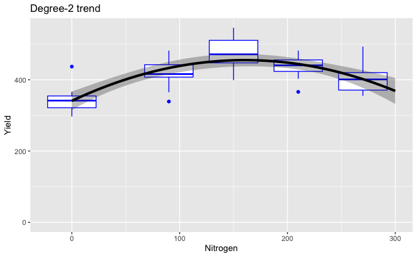

```r
# The output of emmeans can be converted to a data.frame to extract both the estimate (emmean) and the bounds of the CI
reduced_trend_means = emmeans(reduced_trend,'Nitrogen',at=list(Nitrogen = seq(0,300,length=100)))
predicted_data <- as.data.frame(summary(reduced_trend_means,level = 0.95))
ggplot(alpine_potato,aes(x=Nitrogen)) +
    geom_boxplot(aes(y=Yield,group = Nitrogen),color = 'blue',position = position_identity()) +
    ggtitle('Degree-2 trend') + expand_limits(y=0) +
    geom_ribbon(data=predicted_data,aes(ymin = lower.CL,ymax=upper.CL),color=0,alpha=0.3)  + # add confidence bounds
    geom_line(data=predicted_data,aes(y=emmean),size=1.5)
```

Even though it’s not safe to use the intervals from the full_model, we can still plot them for comparison

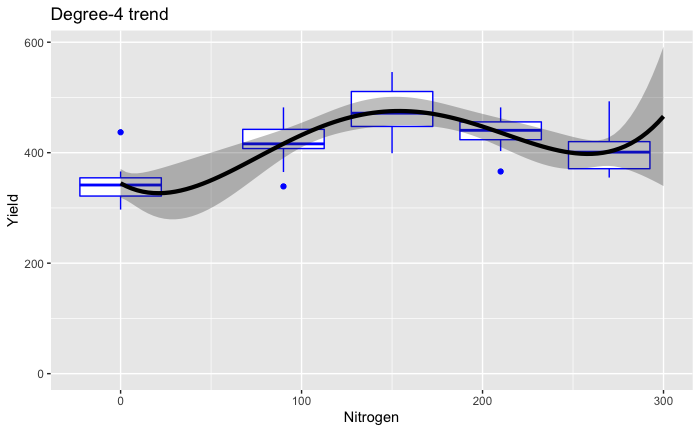

```r
full_trend_means = emmeans(full_trend,'Nitrogen',at=list(Nitrogen = seq(0,300,length=100)))  # use the `full_trend` model instead of the `reduced_trend` model
predicted_data <- as.data.frame(summary(full_trend_means,level = 0.95))
ggplot(alpine_potato,aes(x=Nitrogen)) +
    geom_boxplot(aes(y=Yield,group = Nitrogen),color = 'blue',position = position_identity()) +
    ggtitle('Degree-4 trend') + expand_limits(y=0) +
    geom_ribbon(data=predicted_data,aes(ymin = lower.CL,ymax=upper.CL),color=0,alpha=0.3)  + # add confidence bounds
    geom_line(data=predicted_data,aes(y=emmean),size=1.5)
```

> Questions

> Compare the predictions and prediction intervals for the full and reduced model

> How biased is the reduced model? Which model has narrower prediction intervals? Why isn’t the width of the prediction intervals constant? What must be changing in the formula for a confidence interval? Which model do you prefer?

## Short-cut for modeling trends.

R includes many shortcuts for writing models. As models get more compicated, these can help make your code easier to read.

A short-cut for writing **polynomial-trend** models is the function **poly**

```r
full_trend_short <- lm(Yield ~ poly(Nitrogen,4),alpine_potato)
```

### ANOVA table for poly() model

This model is equivalent to the one we used above (`full_trend`) - it fits a degree-4 polynomial. However, due to some quirks with R, the `anova()` function won’t give a full anova table for this model. Instead, to evaluate the importance of each of the terms, use the `summary` function

```r
summary(full_trend_short)
```

```
Call:
lm(formula = Yield ~ poly(Nitrogen, 4), data = alpine_potato)

Residuals:
   Min     1Q Median     3Q    Max
-77.20 -26.95  -1.75  21.05  92.40

Coefficients:
                   Estimate Std. Error t value Pr(>|t|)
(Intercept)         414.860      5.761  72.018  < 2e-16 ***
poly(Nitrogen, 4)1  153.938     40.733   3.779  0.00046 ***
poly(Nitrogen, 4)2 -245.958     40.733  -6.038 2.74e-07 ***
poly(Nitrogen, 4)3  -30.034     40.733  -0.737  0.46475
poly(Nitrogen, 4)4   83.354     40.733   2.046  0.04659 *
---
Signif. codes:  0 ‘***’ 0.001 ‘**’ 0.01 ‘*’ 0.05 ‘.’ 0.1 ‘ ’ 1

Residual standard error: 40.73 on 45 degrees of freedom
Multiple R-squared:  0.5521,    Adjusted R-squared:  0.5123
F-statistic: 13.87 on 4 and 45 DF,  p-value: 1.901e-07
```

Compare this to `anova` on `full_trend`

```r
anova(full_trend)
```

```
Analysis of Variance Table

Response: Yield
              Df Sum Sq Mean Sq F value    Pr(>F)
I(Nitrogen)    1  23697   23697 14.2822 0.0004603 ***
I(Nitrogen^2)  1  60495   60495 36.4608 2.739e-07 ***
I(Nitrogen^3)  1    902     902  0.5436 0.4647527
I(Nitrogen^4)  1   6948    6948  4.1876 0.0465906 *
Residuals     45  74664    1659
---
Signif. codes:  0 ‘***’ 0.001 ‘**’ 0.01 ‘*’ 0.05 ‘.’ 0.1 ‘ ’ 1
```

Things to note:

1. The p-values for each term are exactly the same.
2. Summary gives Residual standard error: 40.73. This is equal to sqrt(MSE) from `anova`. The degrees of freedom for Residuals is also the same.
3. Instead of `Sum Sq`, we get `Estimate`. `Estimate^2` is equal to `Sum Sq`. This is like the difference between `t` and `F`.